# Lecture_10

Juanita Gil

4/15/2022

# Viewing Alignments

Now that we have aligned reads to a reference genome after quality review and trimming, let’s look at the alignment files. We are going to use the Interactive Genome Viewer (IGV), a tool that allows us to view alignments in an interactive way.

First, go to [pinnacle portal](https://pinnacle-portal.uark.edu/pun/sys/) dashboard and click on Interactive Apps. Select IGV from the pull-down menu. You should see the following:

[figure not shown]

Then click Launch!

Your window should have changed to this once the session starts:

[figure not shown]

Now you click in the blue button that says **“Launch IGV”** Then you will see the screen with IGV running, and it is GUI (Graphical User Interface), where we can start evaluating the files derived from the mapping.

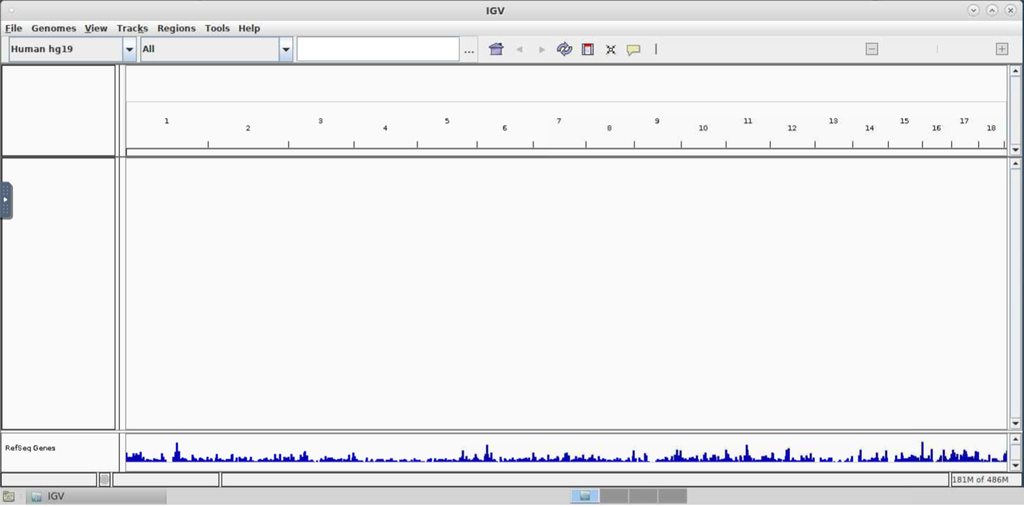

## Uploading the files to IGV

### Upload reference genome:

Go to Genomes -> Load Genome from File.. and select your reference genome (.fna file) from the data folder. Click Open.

### Upload alignment file:

Go to Files -> Load from File.. and select your sorted bam file from the results/bam folder. Click Open.

### Upload annotation file:

Go to Files -> Load from File.. and select the gff file from your data folder. Click Open.

Once you have all the files loaded, to view the alignments, select one of the chromosomes from the pull-down menu. Use the `+` button to zoom in and view the reads.

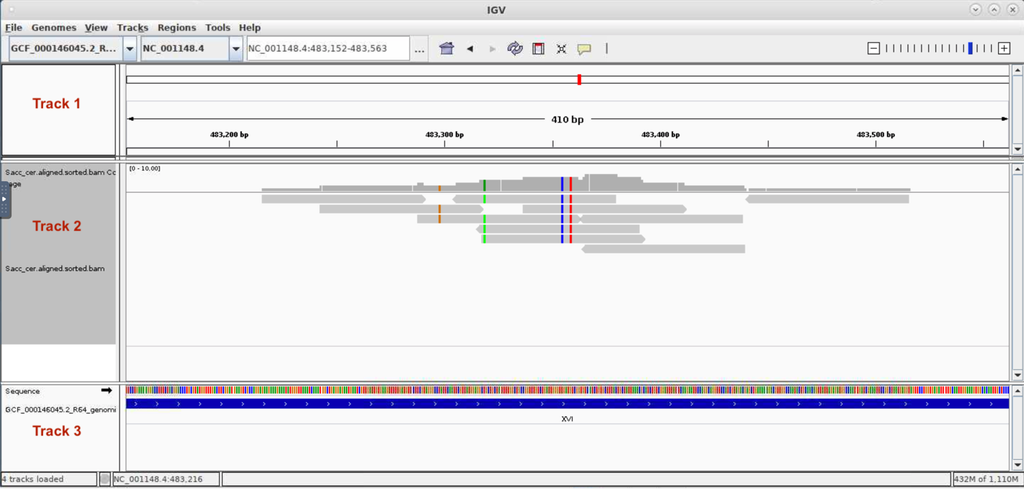

### Interpreting the colors in IGV

- **SNPs** are shown in different colors according to the base.
- **Small insertions** are indicated by a purple ‘I’. When the mouse arrow is pointed on the insertion, a pop-up box shows the inserted bases.
- When the arrow is pointed at a specific read, a pop-up box appears with details on the specific read, e.g., read name, alignment start, mapping quality, base phred quality, insert size, etc.
- At high resolution, the **specific base or variant site** that falls at the center of the IGV window is marked by two vertical dashed lines. When a variant site has an allele that is different from reference in more than 25% of reads, the alternate allele is indicated in a different color.
- A **deletion** is indicated by a black horizontal bar within gaps in a read.
- An **insert size** that is smaller than expected is represented as a blue bar.
- Reads that are colored red have larger than expected inferred sizes.